# CH05 기본 분석

Bora Lee (mintbora0125@gmail.com)

## **Checking normality**

- 모수적 검정 vs. 비모수적 검정

군별 표본수

판단방법

N<10

비모수적 검정 선택

10≤N<30

정규성 검정 수행 후 선택

N≥30

1. 정규성 검정 후 판단
2. 중심극한 정리에 의해 모수적 검정 선택
3. 심하게 왜곡된 분포나 이상치가 많은 경우 비모수적 검정 선택
- 정규성 판단 방법
  1. plot (histogram, boxplot, QQ plot)
  2. Statistical test
     - H0 : 정규성을 따른다
     - H1 : 정규성을 따르지 않는다
- 정규성 검정 종류
  - Shapiro-Wilk test
    - 대표본에서 작은 정규성 이탈에도 민감한 편
    - N이 3~5000개 사이일 때 검정 가능
  - Kolmogorov-Smirnov test
    - 자료의 누적빈도를 통해 통계량 계산
    - 이상치의 영향을 받는 편
  - Lilliefors test
    - Kolmogorov-Smirnov test에서 자유도를 수정한 방법

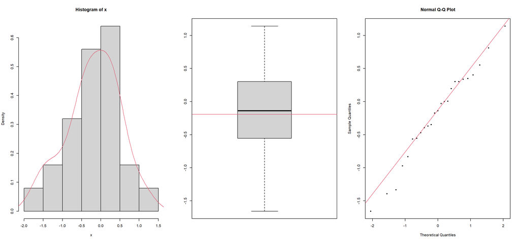

```r
# 표준정규분포를 따르는 25개 random number 생성하기
x <- rnorm(25)

# Graphical method
par(mfcol=c(1,3))
hist(x, probability=T); lines(density(x), col=2)
boxplot(x); abline(h=mean(x), col=2)
qqnorm(x, pch=20); qqline(x, col=2)
```

```r
# Statistical test
shapiro.test(x)
nortest::lillie.test(x)
```

```
##
##  Shapiro-Wilk normality test
##
## data:  x
## W = 0.97684, p-value = 0.8162
```

```
##
##  Lilliefors (Kolmogorov-Smirnov) normality test
##
## data:  x
## D = 0.094496, p-value = 0.8174
```

## **Mean comparison**

#### **One sample**

- 검정 방법
  - 모수적 방법 : one sample t-test
  - 비모수적 방법 : Wilcoxon’s signed rank test
- 일표본 T검정의 예시
  - H0 : 수검자들의 혈압 평균은 90이다
  - H1 : 수검자들의 혈압 평균은 90이 아니다

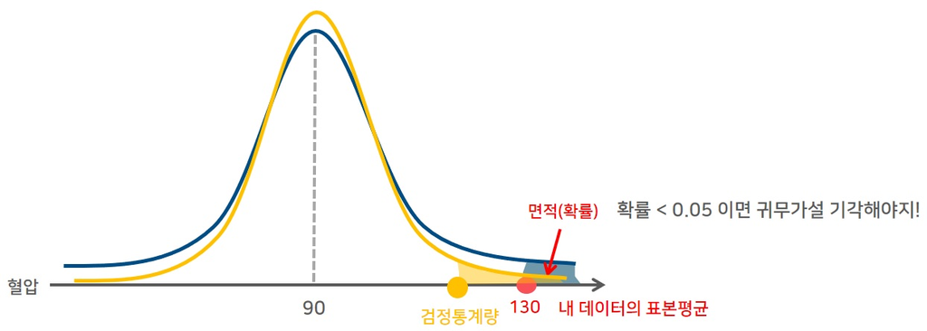

- `t.test(x, mu=0, alternative="two.sided", conf.level=0.95)`
  - x : 비교하고자 하는 관측벡터
  - mu : 비교하고자 하는 기준값
  - alternative : 대립가설 형태 (“two.sided”, “less”, “greater”)
  - conf.level : 신뢰구간의 신뢰수준
- Example

내측측부인대와 전방십자인대 환자들은 보통 부상 후 첫번째 MRI 촬영까지15일정도 걸린다고 알려져 있다. 이를 확인하기 위해, 2000년 12월에서부터 2010년 12월까지 급성 ACL이었거나 등급 3의 MCL이었던 20명의 환자들에 대한 데이터를 수집하였다. 부상에서부터 첫번째 MRI 촬영까지 걸린 시간은 15일인지에 대한 일표본 T검정을 수행하시오. [시트명: mri]

```r
library(readxl)

dpath <- "C:/Users/mintb/Desktop/"
data <- read_excel(paste0(dpath, "data_basic_analysis.xlsx"), sheet="mri")

attach(data)

# 요약통계량
length(daytoMRI)
mean(daytoMRI)
sd(daytoMRI)


# 정규성 검정
shapiro.test(daytoMRI)

# One sample t-test
t.test(x=daytoMRI, mu=15)


# Boxplot with reference line
library(ggplot2)
ggplot(data) +
    geom_boxplot(aes(y=daytoMRI), fill="lightblue", width=0.3) +
    geom_hline(yintercept=15, linetype=6, color="firebrick3", size=1.3) +
    ylab("Day to MRI") +
    xlim(-0.5, 0.5)

detach(data)
```

- Sign test (부호검정)
  - 기준값 대비 차이의 부호 개수를 양, 음별로 계산한 뒤 비교하는 방식

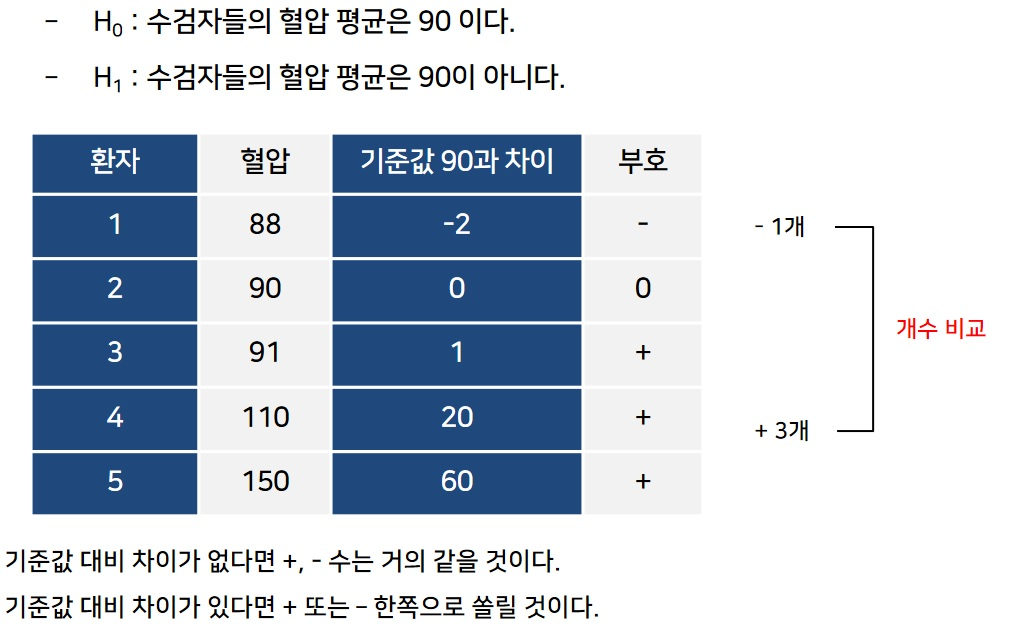

- Wilcoxon’s signed rank test (부호순위검정)
  - 기준값 대비 차이의 절대값이 작은순으로 순서를 붙여 양/음 부호별 합을 비교하는 방식

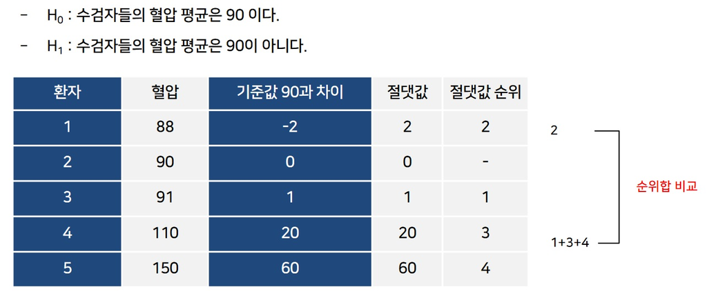

- `wilcox.test(x, mu=0, alternative="two.sided", exact=NULL, correct=T)`
  - x : 비교하고자 하는 관측벡터
  - mu : 비교하고자 하는 기준값
  - alternative : 대립가설 형태 (“two.sided”, “less”, “greater”)
  - exact : TRUE인 경우 정확검정에 의한 p-value 계산 / 단, 표본수가 50개 미만이면서 동률이 없는 경우에만 해당. FALSE인 경우 정규근사에 의한 p-value가 계산됨
  - correct : 정규근사 시 연속성 수정 여부
- Example

Concentration의 평균이 1인지 유의수준 0.05하에서 검정하시오.[시트명: concentration]

```r
data <- read_excel(paste0(dpath, "data_basic_analysis.xlsx"), sheet="concentration")

attach(data)

# 요약통계량
length(concentration)
summary(concentration)

# 정규성 검정
shapiro.test(concentration)

# Wilcoxon's signed rank test
wilcox.test(concentration, mu=1)

summary(concentration)

detach(data)
```

#### **Independent two samples**

- 검정 방법
  - 모수적 방법 : Independent t-test (Student’s t-test)
  - 비모수적 방법 : Wilcoxon’s ranksum test (Mann-Whitney U test)
- 독립표본 T검정의 예시
  - 등분산가정 여부 결정 필요

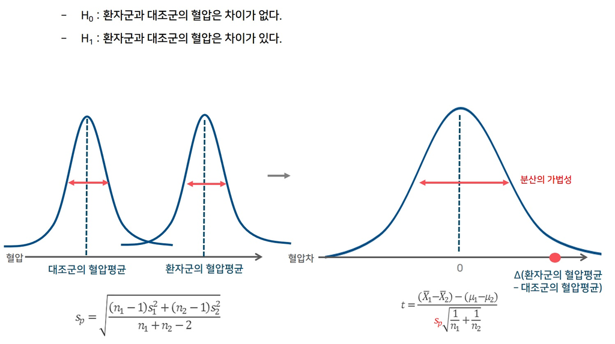

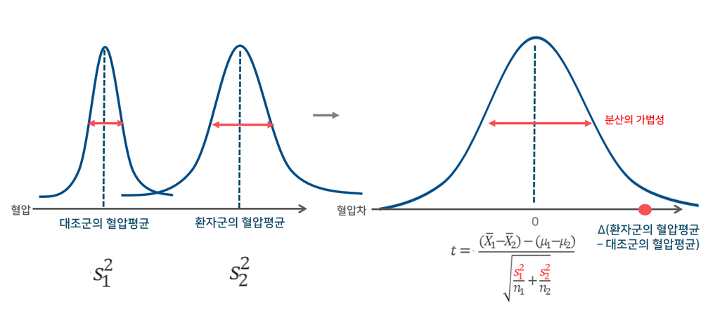

- 등분산검정

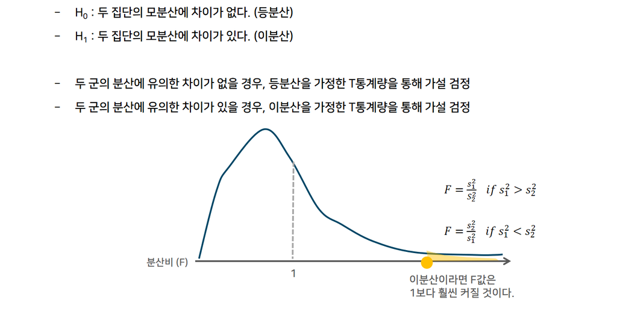

- `t.test(formula, data, mu=0, alternative="two.sided", conf.level=0.95, var.equal=F)`
  - formula : (종속변수) ~ (그룹변수) 형태로 지정
  - data : 종속변수와 그룹변수가 들어있는 데이터셋명. R 환경에 불러져 있는 종속변수와 그룹변수 벡터를 이용하는 경우 지정 불필요
  - mu : 비교하고자 하는 모평균의 차이
  - alternative : 대립가설 형태 (“two.sided”, “less”, “greater”)
  - conf.level : 신뢰구간의 신뢰수준
  - var.equal : 등분산 가정 여부. TRUE이면 등분산가정, FALSE이면 이분산가정
- `car::leveneTest(formula, data, center=median)`
  - formula : (종속변수) ~ (그룹변수) 형태로 지정
  - data : 종속변수와 그룹변수가 들어있는 데이터셋명. R 환경에 불러져 있는 종속변수와 그룹변수 벡터를 이용하는 경우 지정 불필요
  - center : 그룹별 대표값을 계산할 때 사용되는 요약통계량 지정. mean 지정 시 original Levene’s test를 수행하고, median 지정 시 robust test로 수정된 버전의 결과 출력
- Example

환자 10명과 정상인 10명이 앉아 있을 때 혈압을 측정한 결과에서 이때 환자군이 대조군에 비하여 혈압 평균이 낮다고 할 수 있는지 유의수준 0.05에서 검정하시오 [시트명: sbp]

```r
data <- read_excel(paste0(dpath, "data_basic_analysis.xlsx"), "sbp")
summary(data)

attach(data)

# 요약통계량
table(group)
tapply(sbp, group, mean)
tapply(sbp, group, sd)


# 정규성 검정
shapiro.test(sbp[group=="patient"])
shapiro.test(sbp[group=="normal"])

tapply(sbp, group, shapiro.test)

# 등분산 검정
car::leveneTest(sbp~group, center=mean)

# two samples t-test
t.test(sbp~group, var.equal=T)


# Boxplot
library(RColorBrewer)

ggplot(data) +
    geom_boxplot(aes(group, sbp, fill=group), width=0.5) +
    guides(fill="none") +
    scale_fill_brewer(palette="Set1") +
    scale_x_discrete(labels=c("Normal", "Patient")) +
    xlab("") +
    ylab("SBP (mmHg)") +
    ylim(80, 200) +
    annotate("text", x=1, y=200, label="p=0.104 by Student's t-test", size=4, )

detach(data)
```

- Wilcoxon’s ranksum test
  - 순위데이터로 변환하여 분포가 겹치는 정도를 나타내는 통계량을 계산

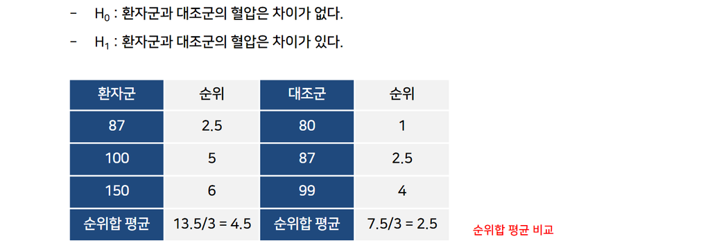

- `wilcox.test(formula, data, mu=0, alternative="two.sided", exact=NULL, correct=T)`
  - formula : (종속변수) ~ (그룹변수) 형태로 지정
  - data : 종속변수와 그룹변수가 들어있는 데이터셋명. R 환경에 불러져 있는 종속변수와 그룹변수 벡터를 이용하는 경우 지정 불필요
  - mu : 비교하고자 하는 중앙값의 차이
  - alternative : 대립가설 형태 (“two.sided”, “less”, “greater”)
  - exact : TRUE인 경우 정확검정에 의한 p-value 계산 / 단, 표본수가 50개 미만이면서 동률이 없는 경우에만 해당. FALSE인 경우 정규근사에 의한 p-value가 계산됨
  - correct : 정규근사 시 연속성 수정 여부
- Example

환자 10명과 정상인 10명이 앉아 있을 때 혈압을 측정한 결과에서 이때 환자군이 대조군에 비하여 혈압 평균이 낮다고 할 수 있는지 유의수준 0.05에서 검정하시오 [시트명: sbp]

```r
data <- read_excel(paste0(dpath, "data_basic_analysis.xlsx"), "sbp")

attach(data)

# 요약통계량
table(group)
tapply(sbp, group, summary)

# Wilcoxon's ranksum test
wilcox.test(sbp~group)

detach(data)
```

#### **Paired two samples**

- 검정 방법
  - 모수적 방법 : Paired t-test
  - 비모수적 방법 : Wilcoxon’s signed rank test
- 대응표본 T검정의 예시

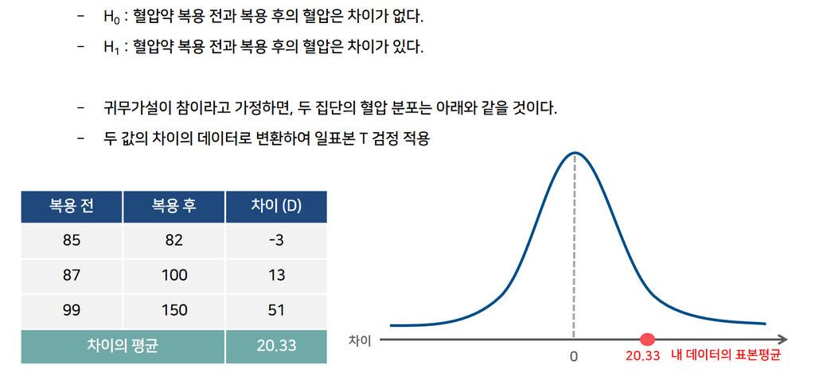

- `t.test(x, y, paired=T, mu=0, alternative="two.sided", conf.level=0.95)`
  - x : 비교하고자 하는 첫 번째 종속변수
  - y : 비교하고자 하는 두 번째 종속변수
  - mu : 비교하고자 하는 두 변수의 모평균의 차이
  - alternative : 대립가설 형태 (“two.sided”, “less”, “greater”)
  - conf.level : 신뢰구간의 신뢰수준
- Example

새롭게 개발한 치료방법이 역류성 식도염 환자에서 효과가 있는지 확인을 하고자, 치료 전후 24시간 식도 내 pH검사를 실시하여, 24시간 중 pH 4 미만인 시간의 비율을 비교하고자 한다. 대응표본 T검정을 이용하여 검정하라.[시트명 : ph4]

```r
data <- read_excel(paste0(dpath, "data_basic_analysis.xlsx"), "ph4")

attach(data)

# 요약통계량
apply(data[,2:3], 2, mean)
apply(data[,2:3], 2, sd)

# 차이값에 대한 정규성 검정
shapiro.test(before - after)

# paired t-test
t.test(before, after, paired=T)

# Boxplot with spaghetti lines
ph <- c(before, after)
time <- rep(c("Before", "After"), each=length(before))
time <- factor(time, levels=c("Before", "After"))
group <- c(id, id)

df <- data.frame(ph, time, group)

ggplot(df, aes(time, ph, col=time)) +
    geom_boxplot(width=0.5) +
    geom_point(pch=20, size=3, color="black") +
    geom_line(aes(group=group), color="black", lty=3) +
    guides(col="none") +
    xlab("") + ylab("Time of PH<4 per day(%)") +
    annotate("text", x=2, y=0, label="p=0.083 by paired t-test", size=4)

detach(data)
```

- Wilcoxon’s signed rank test
  - 두 값의 차이에 대한 비모수적 검정과 동일한 형태

[figure not shown]

- `wilcox.test(x, y, paired=T, mu=0, alternative="two.sided", exact=NULL, correct=T)`
  - x : 비교하고자 하는 첫 번째 종속변수
  - y : 비교하고자 하는 두 번째 종속변수
  - mu : 비교하고자 하는 두 변수의 중앙값의 차이
  - alternative : 대립가설 형태 (“two.sided”, “less”, “greater”)
  - exact : TRUE인 경우 정확검정에 의한 p-value 계산 / 단, 표본수가 50개 미만이면서 동률이 없는 경우에만 해당. FALSE인 경우 정규근사에 의한 p-value가 계산됨
  - correct : 정규근사 시 연속성 수정 여부
- Example

새롭게 개발한 치료방법이 역류성 식도염 환자에서 효과가 있는지 확인을 하고자, 치료 전후 24시간 식도 내 pH검사를 실시하여, 24시간 중 pH 4 미만인 시간의 비율을 비교하고자 한다. 대응표본 T검정을 이용하여 검정하라.[시트명 : ph4]

```r
data <- read_excel(paste0(dpath, "data_basic_analysis.xlsx"), "ph4")

attach(data)

# 요약통계량
summary(before)
summary(after)

# Wilcoxon's signed rank test
wilcox.test(before, after, paired=T)

detach(data)
```

## **Proportion comparison**

#### **Chi-square test**

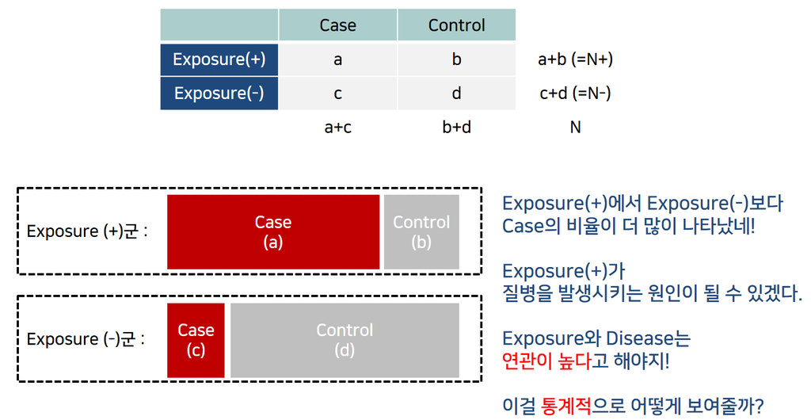

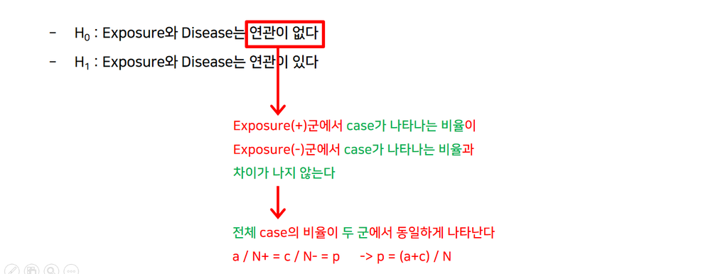

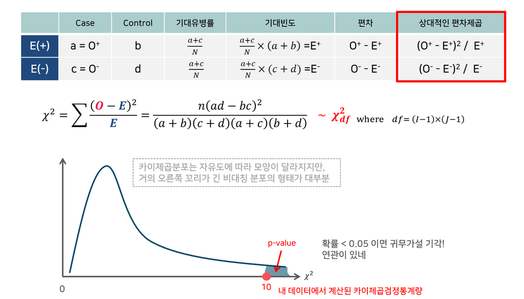

- `chisq.test(x, y=NULL, correct=T)`
  - x : 행에 들어갈 변수 또는 비교하고자 하는 행렬
  - y : 열에 들어갈 변수. x에 행렬이 지정된 경우 무시됨
  - correct : Yates’ correction 적용 여부
- Example Ghali, et al (1992) 연구에서는 아동기 횡문근육종(rhabdomyosarcoma, RMS) 연구의 매칭된 데이터를 일반적인 데이터로 간주하여, 산모의 사산과거력과 횡문근육종 발생이 연관이 있는지 카이제곱검정을 수행하시오. (시트명 : rms)
  - id : 순번
  - rms : 횡문근육종 (0=no, 1=yes)
  - stlbn : 산모의 사산과거력 (0=no, 1=yes)

```r
data <- read_excel(paste0(dpath, "data_basic_analysis.xlsx"), "rms")

attach(data)

# 빈도표
table(rms, stlbn)
prop.table(table(rms, stlbn), 2)

x <- table(rms, stlbn)
y <- round(prop.table(x, 2)*100, 1)

result <- matrix(paste0(x, " (", y, "%)"), nrow=2)
rownames(result) <- c("Normal", "RMS")
colnames(result) <- c("None", "Stillbirth")

# 카이제곱검정
chisq.test(rms, stlbn)
chisq.test(x)

# Bar plot
ggplot(data) +
    geom_bar(aes(x=stlbn, fill=factor(rms)), position="fill", width=0.6) +
    scale_x_continuous(breaks=c(0,1), labels=c("None", "Stillbirth")) +
    labs(x="", y="Proportion", fill="") +
    scale_fill_manual(values=c("lightgray", "firebrick3"), labels=c("Normal", "RMS")) +
    theme_bw() +
    annotate("text", x=c(0, 1), y=c(0.443, 0.808)-0.02, label=c("44.3%", "80.8%"), size=4, col="white") +
    ylim(0,1.1) +
    annotate("text", x=0.5, y=1.1, label="p=0.001 by chi-squared test", size=4)

detach(data)
```

#### **Fisher’s exact test**

- 카이제곱검정의 타당성
  - 2x2 분할표의 경우 20<n<40이면서 각 셀의 기대도수가 모두 5 이상이거나, n>40이어야 함
  - IxJ 분할표의 경우 기대도수가 5이하인 셀이 전체 셀의 20% 이하이고, 1보다 작은 기대도수를 가지는 셀이 없어야 함
- Fisher’s exact test
  - 카이제곱검정의 타당성을 만족하지 못하는 경우 해당 행이나 열을 합하여 pooling 하거나, Fisher’s exact test 수행
  - 예시

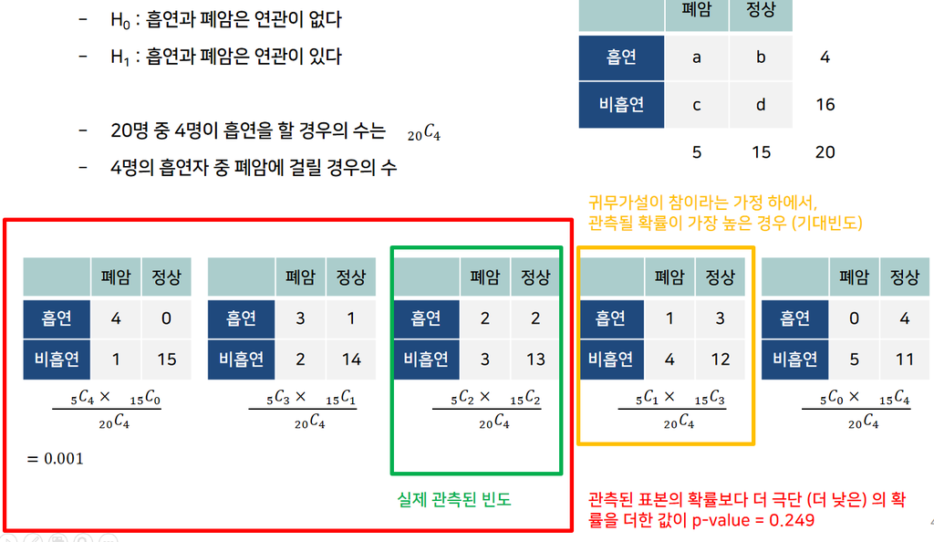

- `fisher.test(x, y=NULL, alternative="two.sided")`
  - x : 행에 들어갈 변수 또는 비교하고자 하는 행렬
  - y : 열에 들어갈 변수. x에 행렬이 지정된 경우 무시됨
  - alternative : 가설검정의 방향 (“two.sided”, “less”, “greater”). 2x2 분할표에서만 적용 가능.
- Example

폐암환자와 정상인에서 아래와 같이 흡연력에 대한 조사결과를 얻었다. 폐암과 흡연 사이에 유의한 연관성이 있는지 검정하시오.

|  | 폐암환자 | 정상인 |
| --- | --- | --- |
| 흡연 | 2 | 2 |
| 비흡연 | 3 | 13 |

```r
# 행렬 입력
tab <- matrix(c(2,3,2,13), nrow=2)

# 카이제곱검정
chisq.test(tab)

# Fisher's exact test
fisher.test(tab)
```

#### **McNemar’s test**

- McNemar’s test
  - 연속형 변수의 분석에서 paired t-test가 있는 것처럼, 범주형 데이터에서도 대응표본에 대한 분석방법 고려 필요
  - 처리 전후 반응 비교에 대해 McNemar(1947)가 제안한 통계량을 이용

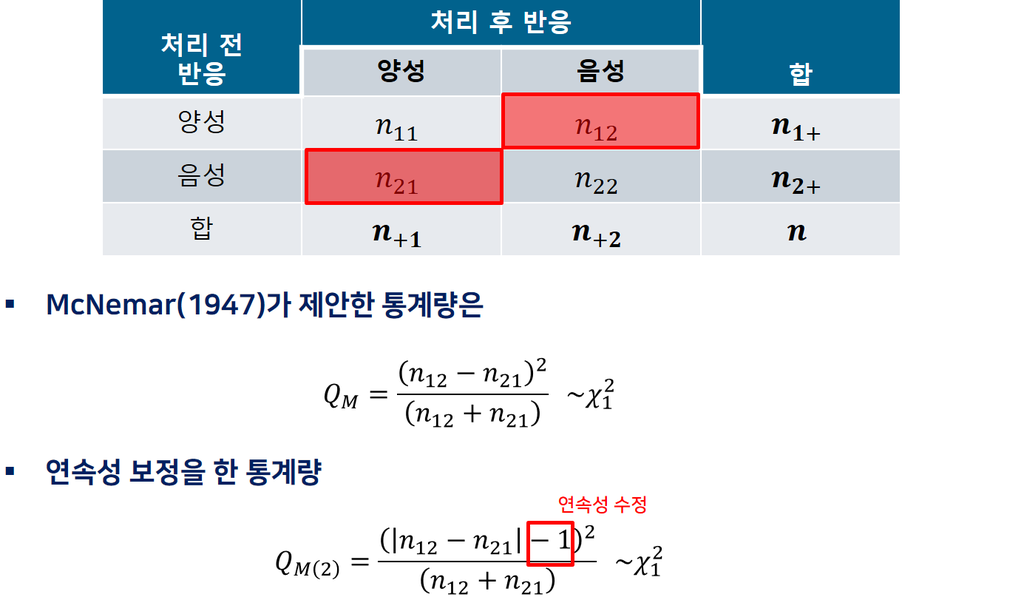

- `mcnemar.test(x, y=NULL, correct=T)`
  - x : 행에 들어갈 변수 또는 비교하고자 하는 행렬
  - y : 열에 들어갈 변수. x에 행렬이 지정된 경우 무시됨
  - correct : 연속성 보정 여부
- Example

결혼한지 3년이 된 남성 60명을 대상으로 결혼 전후의 경제생활의 만족도를 조사한 자료이다. 결혼 전과 결혼 후의 경제생활의 만족도에 있어서 차이가 있는지 알아보자.

|  | 결혼후 만족 | 결혼후 불만족 |
| --- | --- | --- |
| 결혼전 만족 | 23 | 18 |
| 결혼전 불만족 | 7 | 12 |

```r
# 행렬 입력
tab <- matrix(c(23, 18, 7, 12), nrow=2)
pp <- round(prop.table(tab)*100,1)

result <- matrix(paste0(tab, " (", pp, "%)"), 2)

# McNemar's test
mcnemar.test(tab)
```

## **Editing results**

- `attributes()`
  - 분석 결과가 담긴 object에서 추출 가능한 목록 표시
  - 이를 이용하여 원하는 결과의 편집 가능

```r
# 환자군과 대조군의 혈압 비교
data <- read_excel(paste0(dpath, "data_basic_analysis.xlsx"), "sbp")


attach(data)

# two samples t-test
xx <- t.test(sbp~group, var.equal=T)

# 속성 확인하기 (xx에서 가져올 수 있는 객체 목록)
attributes(xx)
```

- 다음 형태의 표 만들어보기

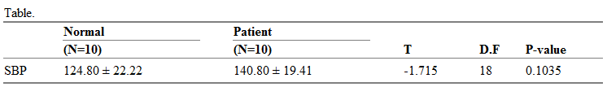

```r
# 요약통계량
n <- table(group)
m <- tapply(sbp, group, mean)
s <- tapply(sbp, group, sd)

m <- round(m, 2)
s <- round(s, 2)

# 결과 정리
re <- paste0(format(m, nsmall=2), " ± ", format(s, nsmall=2))
tstat <- round(xx$statistic, 3)
df <- xx$parameter
pv <- round(xx$p.value, 4)

# 결과 조합
result <- matrix(c(re, tstat, df, pv), nrow=1)
rownames(result) <- "SBP (mmHg)"
colnames(result) <- c("Normal (N=10)", "Patient (N=10)", "T", "D.F", "P-value")

# CSV 파일로 내보내기
write.csv(result, file=paste0(dpath, "result.csv"))

detach(data)
```

```r
library(readxl)
dpath <- "C:/Users/mintb/Desktop/"
data <- read_excel(paste0(dpath, "data_basic_analysis.xlsx"), "sbp")

# two samples t-test
xx <- t.test(sbp~group, data=data, var.equal=T)

# 요약통계량
n <- table(data$group)
m <- tapply(data$sbp, data$group, mean)
s <- tapply(data$sbp, data$group, sd)

m <- round(m, 2)
s <- round(s, 2)

re <- paste0(format(m, nsmall=2), " ± ", format(s, nsmall=2))
tstat <- round(xx$statistic, 3)
df <- xx$parameter
pv <- round(xx$p.value, 4)

result <- matrix(c(re, tstat, df, pv), nrow=1)
rownames(result) <- "SBP (mmHg)"
colnames(result) <- c("Normal (N=10)", "Patient (N=10)", "T", "D.F", "P-value")

result
```

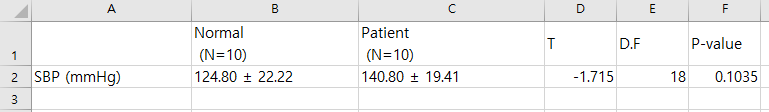

## **moonBook::mytable()**

- `mytable(x, data, max.ylev=5, digits=1, method=1, catMethod=2, show.all=F, show.total=F)`
  - x : formula 형태로 작성. 군 ~ 변수1 + 변수2 의 형태로 작성. 데이터셋 내의 모든 변수를 정리하고 싶은 경우 ‘.’ 입력
  - data : 분석에 활용할 데이터셋 지정. 미지정시 분석 안됨.
  - max.ylev : 연속형 변수라도 범주가 5개 미만이면 그룹변수로 인식하여 범주형 자료분석 수행
  - method : 연속형 변수 검정 방법 선택 (1=모수적 검정, 2=비모수적 검정, 3=정규성검정결과에 따라 판단)
  - catMethod : 범주형 변수 검정 방법 선택 (0=카이제곱먼저 수행 후 타당성 문제 시 Fisher’s test 수행, 1=연속성수정없는 카이제곱검정 수행, 2=연속성수정하는 카이제곱검정 수행, 3=Fisher’s test 수행, 4=trend test 수행)
  - show.all : 모든 통계적 검정 결과 출력
  - show.total : 그룹변수가 formula에 포함된 경우더라도 TRUE이면 전체 변수의 통계량 출력

```r
library(moonBook)

# 환자군과 정상군에서 SBP 비교
data <- read_excel(paste0(dpath, "data_basic_analysis.xlsx"), "sbp")
mytable(group~sbp, data=data)

# 산모의 사산과거력에 따른 RMS 비율 비교
data <- read_excel(paste0(dpath, "data_basic_analysis.xlsx"), "rms")
mytable(stlbn~rms, data=data, catMethod=0)
```

**THE END**